# ANU Student Research Conference Workshop: Introduction to R https://bit.ly/2kGO4I1

Dr. Marcin Adamski marcin.adamski@anu.edu.au

21 September 2019

This document was created in R Markdown (http://rmarkdown.rstudio.com, http://rmarkdown.rstudio.com/articles_intro.html). R Markdown documents can be easily created in RStudio.

# Learning Objectives

- Basic concepts and skills
  - Getting familiar with RStudio
    - Panels in RStudio IDE (Integrated Development Environment)
    - Concept of RStudio Project and creating a new one
    - Creating new script file
    - Running script line-by-line
  - Proper commenting of the code
  - Using R as calculator
  - Getting Help
  - Variable and data types
    - naming variables
    - listing and removing variables
  - Operators
    - Arithmetic
    - Logical
  - Homogenous Data Structures
    - vectors
    - matrices
  - Heterogeneous Data Structures
    - Data frames
    - Lists
  - Installing a package

# Our Example Project: Eccology of Golden Orb-Weaver Spiders

We will get a taste of how to analyze data in R by working with data from (a fictionary) project on Golden Orb-Weaver spiders. The research objective of this project is to compare spider populations living in different climate zones in Australia. We will compare body weight of a spider to the diameter of the web the spider weaves and asses if it is true that:

1. Bigger and heavier spiders make larger webs.
2. The climate where spiders live has an effect on their weight and size of the web.

We will learn how to load data, calculate basic statistics, and test hypothesis for statistical significance. In the process we will create some plots and graphs.  
But before we start all of it, we first need to get a bit more familiar with R and RStudio.

# Introduction

## What is R?

**R** is an open source programming language and software environment for statistical computing and graphics that is supported by the R Foundation for Statistical Computing. The R language is widely used among statisticians and data miners for developing statistical software and data analysis.

R and its libraries implement a wide variety of statistical and graphical techniques, including linear and nonlinear modeling, classical statistical tests, time-series analysis, classification, clustering, and others.

R is easily extendable through functions and modules, and the R community is noted for its active contributions in terms of packages.

Many of R’s standard functions are written in R itself, which makes it easy for users to follow the algorithmic choices made. For computationally intensive tasks, C, C++, and Fortran code can be linked and called at run-time (quoted from R - programming language). You can download and install R from [here](https://cran.rstudio.com/).

## What is RStudio?

R Studio (written as RStudio without the space) is a free and open-source Integrated Development Environment (IDE) for R. You can download RStudio from [here](https://www.rstudio.com/products/rstudio/download/#download). RStudio makes our expirience with R easier, but it is not necessary to program in R.

## First steps

### Calculator

Almost all introductory R courses begin from using R as a calculator… We will do the same. Let’s type the formulas (expressions) below and click <Ctrl-ENTER> on PC or <Cmd-ENTER> on Mac.

```r
#now, we use R as a calculator (order of operators is: (), ^, /, *, +, -):
2 + 2
```

```
## [1] 4
```

```r
#we can force the order using parenthesises
3 + 5 * 2 ^ 2
```

```
## [1] 23
```

```r
(1 + 2) * 3
```

```
## [1] 9
```

```r
#or use scientific notation
2e-4 + 1e-6
```

```
## [1] 0.000201
```

We can use bulit-in functions

```r
log(1)
```

```
## [1] 0
```

```r
log10(100)
```

```
## [1] 2
```

```r
sin(1)
```

```
## [1] 0.841471
```

```r
sin(pi)
```

```
## [1] 1.224606e-16
```

Our R-calculator can plot!

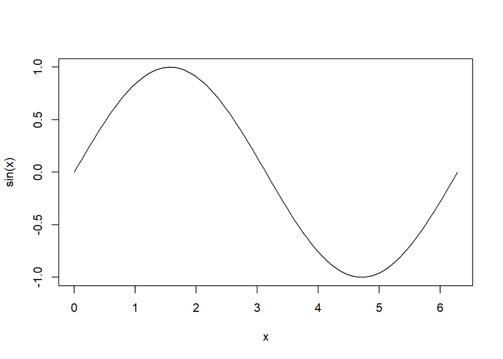

```r
curve(sin, from = 0, to = 2 * pi, n = 100)
```

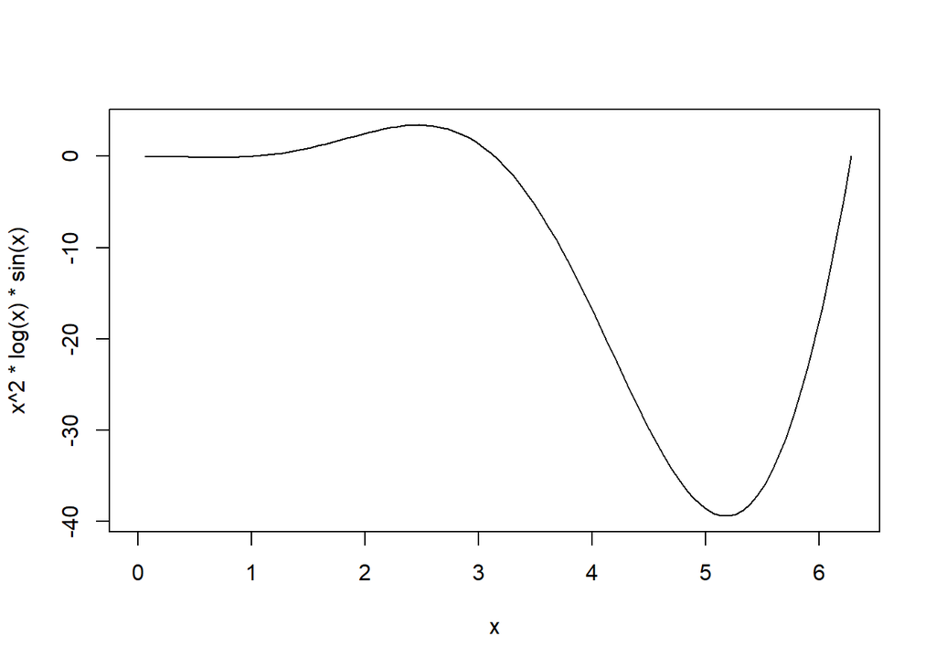

```r
#we can use more complicated expression which uses 'x' as a variable
curve(x^2 * log(x) * sin(x), from = 0, to = 2 * pi, n = 100)
```

R can also work with text:

```r
#output text
"Hello World!"
```

```
## [1] "Hello World!"
```

```r
#use bulit-in function print() to print:
print("Hello World!")
```

```
## [1] "Hello World!"
```

```r
#concatenate parts to get one string of text:
print(paste("Answer to", "the Ultimate Question of Life, the Universe, and Everything is", 2^5 + 2^3 + 2^1))
```

```
## [1] "Answer to the Ultimate Question of Life, the Universe, and Everything is 42"
```

### HELP!!!

How to get help in R:

https://www.r-project.org/help.html

- use function `help()`

```r
help("print")
```

- instead of `help()` you can use `?` shortcut

```r
? print
```

- or use `??` to search the help topics

```r
??print
```

### Variables and data types

We have already mentioned variables. Now, we will have a closer look at them and the **assignments**.

We can assign numerical values or results of numerical operations:

```r
x <- 1 / 10   #'<-' is an assignment operator; you can enter it with one keystroke as Alt + _ (underscore)
x
```

```
## [1] 0.1
```

```r
x <- 1000   #notice how RStudio updates its description of x on the top right 'Environment' tab
x < - 10    # ***** BE CAREFUL WITH SPACES!!!! *****
```

```
## [1] FALSE
```

```r
x
```

```
## [1] 1000
```

```r
log10(x)
```

```
## [1] 3
```

```r
2 * x
```

```
## [1] 2000
```

Variables do not need to be only numbers. We can use different *data types*:

```r
isGood    = TRUE      #logical or boolean
myNumber  = 0.25      #numeric float or double
myInteger = 2L        #numeric integer or long
myName    = "Marcin"  #character or text
```

To check type of the data use the `typeof()` function

```r
typeof(isGood)
```

```
## [1] "logical"
```

```r
typeof(myNumber)
```

```
## [1] "double"
```

```r
typeof(myName)
```

```
## [1] "character"
```

Not all names of variables are equally good. Variable names can contain letters (upper and lower), numbers (but they can’t start with a digit), underscores, and dots (but if they start from a dot they are ‘hidden’):

```r
#examples of bad variable names
12_from_the_left <- 12     #starting with a number
my name <- "Marcin"        #contains space
me@home <- 2               #contains non-alphanumeric symbol
```

We have learnt that a variable is created when a value is assigned to if for the first time. But how to list all the variables? How to delete variables?  
To list variables we use the *list* functions `ls()` (or we can consult the **Environment** panel in RStudio).

```r
ls()
```

```
## [1] "isGood"    "myInteger" "myName"    "myNumber"  "x"
```

To *remove* a variable we use remove function `rm()` (or use the *broom* icon in the **Environment** panel in RStudio).

```r
rm(myName)

#to remove all variables we use
rm(list = ls())
```

Do you know how the `rm(list = ls())` actually worked?  
How to delete a sub-set of variables using one rm() function?

### Relational Operators

Relational operators are used to compare objects, e.g. variables, numbers. The result is a logical value - `TRUE` or `FALSE`.

```r
#exactly equal:
1 == 1   #please note the doube '='
```

```
## [1] TRUE
```

```r
1 == 0
```

```
## [1] FALSE
```

```r
#less than:
1 < 0
```

```
## [1] FALSE
```

```r
#more than:
1 > 0
```

```
## [1] TRUE
```

```r
#more than or equal:
1 >= 0
```

```
## [1] TRUE
```

```r
#less then or equal:
1.2 <= 1.2
```

```
## [1] TRUE
```

### Logical operators

Logical operators are used to carry out Boolean operations like `AND`, `OR`, `NOT`.

`OR` operator, symbol `|`

[output not shown]

`AND` operator, symbol `&`

[output not shown]

`NOT` operator, symbol `!`

| A | !A |
| --- | --- |
| `FALSE` | `TRUE` |
| `TRUE` | `FALSE` |

Let’s give the logical opeartors a try:

```r
#simple comparisons, no logical operators:
1 > 0
```

```
## [1] TRUE
```

```r
1 > 2
```

```
## [1] FALSE
```

```r
#logical OR:
1 > 0 | 1 > 2
```

```
## [1] TRUE
```

```r
#logical AND:
1 > 0 & 1 > 2
```

```
## [1] FALSE
```

```r
#logical NOT:
!(1 > 0)
```

```
## [1] FALSE
```

### Operator Precedence and Associativity

As we all remember from our preschool algebra classes operators have their ‘priority’ or *precedence* - the order in which they are used in calculations. The table below is a short summary of precedencing order of the more common operators in R.

> It’s always possible to force the precedence with the parentheses: `(` `)`

| Operator | Description | Associativity |
| --- | --- | --- |
| ^, ** | Exponent | Right to Left |
| -x, +x | Unary minus, Unary plus | Left to Right |
| : | sequence | Left to Right |
| %*any*% | *special* operators, e.g. %in%, %*% | Left to Right |
| *, / | Multiplication, Division | Left to Right |
| +, – | Addition, Subtraction | Left to Right |
| <, >, <=, >=, ==, != | Comparisions | Left to Right |
| ! | Logical NOT | Left to Right |
| & | Logical AND | Left to Right |
| \| | Logical OR | Left to Right |
| ->, ->> | Rightward assignment | Left to Right |
| <-, <<- | Leftward assignment | Right to Left |
| = | Leftward assignment | Right to Left |